```r
library(data.table)
library(igraph)
library(stringr)
library(splitstackshape)
library(plotly)
library(network)
library(lubridate)
library(readxl)
library(lubridate)
library(dplyr)
library(parallel)
```

```r
#import the data
invest1 <- fread("C:/Users/10331/OneDrive/Desktop/Funding_events_7.14.csv",header = TRUE)
invest2 <- fread("C:/Users/10331/OneDrive/Desktop/Funding_events_7.14_page2.csv",header = TRUE)
```

```r
perform <- fread("C:/Users/10331/OneDrive/Desktop/Venture_capital_firm_outcomes.csv",header = TRUE)
```

```r
#combine the tables
invest <- rbindlist(list(invest1,invest2))
head(invest)
```

```
##     Portfolio Company Name           Website                    Stage Deal Date
## 1:                #waywire   www.waywire.com                     Seed   6/30/12
## 2:                #waywire   www.waywire.com                   Add-on   10/1/13
## 3: (the) One of them, Inc.  www.oneofthem.jp        Unspecified Round   10/4/11
## 4:              +plugg srl www.plusplugg.com        Unspecified Round    7/1/12
## 5:             @Futsal Ltd   ww.futsaluk.net        Unspecified Round    2/2/09
## 6:                 @Source  www.source.co.za Growth Capital/Expansion    6/1/08
##    Deal Size DealSize (USD mn) DealSize (EUR mn) Total Known Funding (USD mn)
## 1:  1.75 USD              1.75              1.43                         1.75
## 2:                          NA                NA                           NA
## 3:                          NA                NA                           NA
## 4:  1.75 EUR              2.15              1.75                         2.15
## 5:  3.25 GBP              4.66              3.63                         4.66
## 6:                          NA                NA                           NA
##    Total Known Funding (EUR mn) Deal Status
```

[output cut: 34 more lines]

```r
#Question1

#For this question, we only have to create a simple igraph. However, for question 2-5, I decided to create a large edge list with all possible combinations, grouping by each time period and excluding the decaying interactions.

library(lubridate)

#transform deal date to date format, and floor it to month for simpler calculations
invest$date <- mdy(invest$`Deal Date`)
invest$month <- floor_date(invest$date,"month")
```

```r
#set a label for each investment by rowid
invest$id <- row.names(invest)
#preview the data
head(invest)
```

```
##     Portfolio Company Name           Website                    Stage Deal Date
## 1:                #waywire   www.waywire.com                     Seed   6/30/12
## 2:                #waywire   www.waywire.com                   Add-on   10/1/13
## 3: (the) One of them, Inc.  www.oneofthem.jp        Unspecified Round   10/4/11
## 4:              +plugg srl www.plusplugg.com        Unspecified Round    7/1/12
## 5:             @Futsal Ltd   ww.futsaluk.net        Unspecified Round    2/2/09
## 6:                 @Source  www.source.co.za Growth Capital/Expansion    6/1/08
##    Deal Size DealSize (USD mn) DealSize (EUR mn) Total Known Funding (USD mn)
## 1:  1.75 USD              1.75              1.43                         1.75
## 2:                          NA                NA                           NA
## 3:                          NA                NA                           NA
## 4:  1.75 EUR              2.15              1.75                         2.15
## 5:  3.25 GBP              4.66              3.63                         4.66
## 6:                          NA                NA                           NA
##    Total Known Funding (EUR mn) Deal Status
```

[output cut: 41 more lines]

```r
#drew the relevant info for analysis to a new dataframe, and preview the dataframe
df <- data.table(investor = invest$Investors, id = invest$id, month = invest$month)
head(df)
```

```
##                                                                                                                                                             investor
## 1:                                                                                                                         First Round Capital, Innovation Endeavors
## 2: Active Angel Investors, Innovation Ventures, Magnify.net, New York Angels, NextStage Capital, Ogden Capital, Rose Tech Ventures, Wilson Sonsini Goodrich & Rosati
## 3:                                                                                                                                           Globis Capital Partners
## 4:                                                                                                                                                            Vertis
## 5:                                                                                                                                                   Foresight Group
## 6:                                                                                                                                                    Horizon Equity
##    id      month
## 1:  1 2012-06-01
## 2:  2 2013-10-01
## 3:  3 2011-10-01
## 4:  4 2012-07-01
## 5:  5 2009-02-01
## 6:  6 2008-06-01
```

```r
#correct the formatting of investors to avoid dupelicates and split the investors into separated columns
df$investor <- str_replace_all(df$investor, ",Inc", "Inc")
df$investor <- str_replace_all(df$investor, ", Inc", "Inc")

df$investor <- str_replace_all(df$investor, ",Ltd", "Ltd")
df$investor <- str_replace_all(df$investor, ", Ltd", "Ltd")

df$investor <- str_replace_all(df$investor, ",LLC", "LLC")
df$investor <- str_replace_all(df$investor, ", LLC", "LLC")

df$investor <- str_replace_all(df$investor, ",LP", "LP")
df$investor <- str_replace_all(df$investor, ", LP", "LP")

df$investor <- str_replace_all(df$investor, ",L.P", "L.P")
df$investor <- str_replace_all(df$investor, ", L.P", "L.P")

df$investor <- str_replace_all(df$investor, ",S.A", "S.A")
df$investor <- str_replace_all(df$investor, ", S.A.", "S.A")

df$investor <- str_replace_all(df$investor, ",Corp", "Corp")
df$investor <- str_replace_all(df$investor, ", Corp", "Corp")

df$investor <- str_replace_all(df$investor, ",a.s.", "a.s.")
df$investor <- str_replace_all(df$investor, ", a.s.", "a.s.")

df$investor <- str_replace_all(df$investor, ",llc", "llc")
df$investor <- str_replace_all(df$investor, ", llc", "llc")

df$investor <- str_replace_all(df$investor, ",LTD", "LTD")
df$investor <- str_replace_all(df$investor, ", LTD", "LTD")

df$investor <- str_replace_all(df$investor, ",corp", "corp")
df$investor <- str_replace_all(df$investor, ", corp", "corp")

df$investor <- str_replace_all(df$investor, ",Co.", "Co.")
df$investor <- str_replace_all(df$investor, ", Co.", "Co.")

df <- cSplit(df,"investor",",")

#preview the data
head(df)
```

```
##    id      month             investor_01          investor_02 investor_03
## 1:  1 2012-06-01     First Round Capital Innovation Endeavors        <NA>
## 2:  2 2013-10-01  Active Angel Investors  Innovation Ventures Magnify.net
## 3:  3 2011-10-01 Globis Capital Partners                 <NA>        <NA>
## 4:  4 2012-07-01                  Vertis                 <NA>        <NA>
## 5:  5 2009-02-01         Foresight Group                 <NA>        <NA>
## 6:  6 2008-06-01          Horizon Equity                 <NA>        <NA>
##        investor_04       investor_05   investor_06        investor_07
## 1:            <NA>              <NA>          <NA>               <NA>
## 2: New York Angels NextStage Capital Ogden Capital Rose Tech Ventures
## 3:            <NA>              <NA>          <NA>               <NA>
## 4:            <NA>              <NA>          <NA>               <NA>
## 5:            <NA>              <NA>          <NA>               <NA>
## 6:            <NA>              <NA>          <NA>               <NA>
##                         investor_08 investor_09 investor_10 investor_11
```

[output cut: 27 more lines]

```r
#make it into a huge pair lists of interactions
pairs <- lapply(seq_len(nrow(df)),function(i) t(df[i,]))
```

```r
#collapse empty columns and reduce the size of whole list, also simplfy the process later on to find all ties.
for (i in seq_along(pairs)){
  pairs[[i]] <- pairs[[i]][!is.na(pairs[[i]])]
}

#preview the list
head(pairs)
```

```
## [[1]]
## [1] "1"                    "2012-06-01"           "First Round Capital"
## [4] "Innovation Endeavors"
##
## [[2]]
##  [1] "2"                                "2013-10-01"
##  [3] "Active Angel Investors"           "Innovation Ventures"
##  [5] "Magnify.net"                      "New York Angels"
##  [7] "NextStage Capital"                "Ogden Capital"
##  [9] "Rose Tech Ventures"               "Wilson Sonsini Goodrich & Rosati"
##
## [[3]]
## [1] "3"                       "2011-10-01"
## [3] "Globis Capital Partners"
##
## [[4]]
## [1] "4"          "2012-07-01" "Vertis"
##
## [[5]]
## [1] "5"               "2009-02-01"      "Foresight Group"
##
## [[6]]
## [1] "6"              "2008-06-01"     "Horizon Equity"
```

```r
#create a reference for spliting pair lists by time period.
months <- seq.Date(min(invest$month),max(invest$month),by="month")
```

```r
#find all ties, by filtering out the investment that has only one investor
tmp <- sapply(seq_along(pairs), function(i) length(pairs[[i]])>3)
```

```r
#use the index just created to filter the data
pairs <- pairs[tmp]
```

```r
#create a edge list out of the pair list, reduce the redundant columns
ties <- lapply(seq_along(pairs), function(i) data.table(t(combn(pairs[[i]][-c(1,2)],2)), id = pairs[[i]][1], month = pairs[[i]][2]))
```

```r
#Combine all the sub-lists in the one list
ties <- rbindlist(ties)
```

```r
#change the labels
colnames(ties)[1:2] = c("from","to")
```

```r
#reorder the data by from/to/month to perform calculation on date
setorderv(ties,c("from","to","month"))

#preview the ties
head(ties)
```

```
##             from                    to    id      month
## 1: .406 Ventures Acadia Woods Partners 18614 2011-08-01
## 2: .406 Ventures  Advance Publications 59653 2013-09-01
## 3: .406 Ventures         Atlas Venture 60314 2007-01-01
## 4: .406 Ventures         Atlas Venture  7825 2007-10-01
## 5: .406 Ventures         Atlas Venture 60319 2009-03-01
## 6: .406 Ventures         Atlas Venture 60316 2009-09-01
```

```r
#find all the previous time of interaction
ties[,previous := c(NA,month[-.N]),by = c("from","to")]
```

```r
#find out the time diff between previous and later interactions
ties$interval <- round(difftime(ties$month,ties$previous,units = "days"))
```

```r
#find the threshold of 90% quantile
ties$threshold = quantile(ties$interval,.9,na.rm = TRUE)
```

```r
#assign 0 to new interactions to aviod null/inf
ties[is.na(ties$interval),"interval"] = 0
```

```r
#find how many times each tie repeated
ties[,repeated := seq_len(.N)-1,by=c("from","to")]

#calcualte cumulative successes
ties[,year:= year(month)]
colnames(perform)[1] <- "investor"
perform2 <- perform[,1:3]
perform2[,successful_investments:= cumsum(successful_investments), by = investor]
colnames(perform2)[3] = "cumulative"

#preview the ties
head(ties)
```

```
##             from                    to    id      month   previous interval
## 1: .406 Ventures Acadia Woods Partners 18614 2011-08-01       <NA>   0 days
## 2: .406 Ventures  Advance Publications 59653 2013-09-01       <NA>   0 days
## 3: .406 Ventures         Atlas Venture 60314 2007-01-01       <NA>   0 days
## 4: .406 Ventures         Atlas Venture  7825 2007-10-01 2007-01-01 273 days
## 5: .406 Ventures         Atlas Venture 60319 2009-03-01 2007-10-01 517 days
## 6: .406 Ventures         Atlas Venture 60316 2009-09-01 2009-03-01 184 days
##    threshold repeated year
## 1: 1127 days        0 2011
## 2: 1127 days        0 2013
## 3: 1127 days        0 2007
## 4: 1127 days        1 2007
## 5: 1127 days        2 2009
## 6: 1127 days        3 2009
```

```r
#create a edge list that contain lists of interactions before specific dates
edges = lapply(seq_along(months), function(i) ties[month <= months[i]])
```

```r
#figure out the tie ages
edges = lapply(seq_along(months), function(i) edges[[i]][, tie_age := round(difftime(months[i],month,units = "days"))])
```

```r
#filtering out those are decaying
edges = lapply(seq_along(months), function(i) edges[[i]][tie_age <= threshold,])
```

```r
#Generate a igraph
g = lapply(seq_along(edges), function(i) graph.data.frame(edges[[i]][,c("from","to","repeated","tie_age")],directed = FALSE))
```

```r
#find the month 2014 July's igraph
tmp <- which(months == "2014-7-1")
g1 = g[[tmp]]
g1
```

```
## IGRAPH 57050e9 UN-- 7040 75280 --
## + attr: name (v/c), repeated (e/n), tie_age (e/n)
## + edges from 57050e9 (vertex names):
##  [1] .406 Ventures--Acadia Woods Partners
##  [2] .406 Ventures--Advance Publications
##  [3] .406 Ventures--Atlas Venture
##  [4] .406 Ventures--Atlas Venture
##  [5] .406 Ventures--Atlas Venture
##  [6] .406 Ventures--Atlas Venture
##  [7] .406 Ventures--Atlas Venture
##  [8] .406 Ventures--Avalon Ventures
## + ... omitted several edges
```

```r
#find the most central company based on Max closeness
close1 = closeness(g1, mode = "total")
tmp = which(close1==max(close1))
close1[tmp]
```

```
## Kleiner Perkins Caufield & Byers
##                     3.212436e-07
```

```r
#find the most central company based on Min average path
avg_path = distances(g1)
avg_path[avg_path == Inf] = nrow(avg_path)
avg_path = apply(avg_path,1,mean)
tmp = which(avg_path==min(avg_path))
avg_path[tmp]
```

```
## Kleiner Perkins Caufield & Byers
##                         442.1736
```

By both min average path and max closeness, Kleiner Perkins Caufield & Byers is the most central firm in the network.

```r
#Question2

#for this question, we want to fin the coreness for each month and then plot out the graph.

#calculate the coreness for each month's igraph
tmp <- lapply(seq_along(g), function(i) mean(coreness(g[[i]])))
```

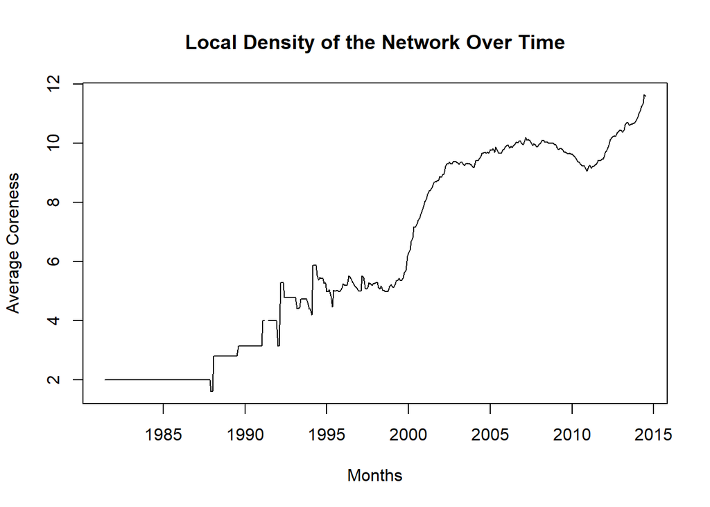

```r
#plot the coreness over time
plot(months, tmp, type = 'l',
     xlab = 'Months', ylab = "Average Coreness", main = 'Local Density of the Network Over Time')
```

```r
#filtering out repeated relationships to get unique ties
tmp<- lapply(seq_along(g), function(i) simplify(g[[i]],remove.multiple = TRUE))
tmp <- lapply(seq_along(tmp), function(i) mean(coreness(tmp[[i]])))
```

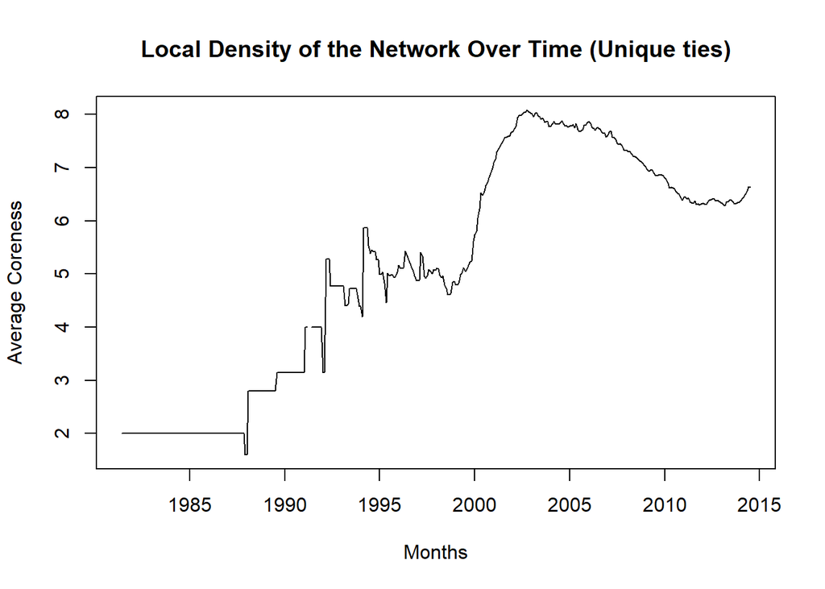

```r
#plot the coreness of unique ties over time
plot(months, tmp, type = 'l',
     xlab = 'Months', ylab = "Average Coreness", main = 'Local Density of the Network Over Time (Unique ties)')
```

Two figures looks nearly identical in shape for the part before 2000. For the part after 2000, the figure for unique ties has relatively lower value and slightly different shape. It might suggest that, at the beginning, the investment companies were forming unique ties and small groups. Then the companies from different groups starts to link, which links the groups they from as well and formed a core. As a complex group/core formed, the companies with in the group tend to co-invest which won’t provide as much unique tie. So the shape in the later part gets lower, because co-invest creates repeated ties instead of unique ties.

```r
# Question3
#(A)
# for simplify the problem, we first select one month from each year before calculate correlation to compute concentration scores. Concentration score comparing to ideal  core-periphery structure with each partition size p should give a nice idea of this question.

#Get all the July's index from each year
tmp <- seq(from = 2, to = length(months), by = 12)

# Use the influence-based similarity (Eigenvector Centrality) to measure the Global Coreness
eigen<- lapply(seq_along(tmp),
               function(i) data.table(
                 node = V(g[[tmp[i]]])$name,
                 eigen_centrality = eigen_centrality(g[[tmp[i]]])$vector,
                 year = i))
eigen <- rbindlist(eigen)
```

```r
# reorder the table with the month(ascending) and eigen_centrality(descending)
setorderv(eigen,c('year','eigen_centrality'), c(1,-1))

#preview the table
head(eigen)
```

```
##                    node eigen_centrality year
## 1:    Greylock Partners                1    1
## 2: Sutter Hill Ventures                1    1
## 3:              Venrock                1    1
## 4: Sutter Hill Ventures                1    2
## 5:              Venrock                1    2
## 6:    Greylock Partners                1    2
```

```r
# calculate the concentration by correlation between the computed actual coreness scores (eigenvector centrality) and the ideal coreness score

corr = lapply(seq_along(tmp),function(i)
  sapply(seq_len(nrow(eigen[year==i])),function(j)
    cor(eigen[year==i, eigen_centrality],
        c(rep(1,j),rep(0,nrow(eigen[year==i])-j)))
         )
  )
```

[output not shown]

[output cut: 52 more lines]

[output not shown]

```r
#reformat the table for plotting
cov_dt<- lapply(seq_along(corr), function(i)
  data.table(index = seq_along(corr[[i]]),
             concentration = corr[[i]],
             year = i))
cov_dt <- rbindlist(cov_dt)
cov_dt[,prop:= index/max(index), by =year]

#preview the table
head(cov_dt)
```

```
##    index concentration year      prop
## 1:     1     0.4714045    1 0.3333333
## 2:     2     0.9428090    1 0.6666667
## 3:     3            NA    1 1.0000000
## 4:     1     0.4472136    2 0.1666667
## 5:     2     0.7071068    2 0.3333333
## 6:     3     1.0000000    2 0.5000000
```

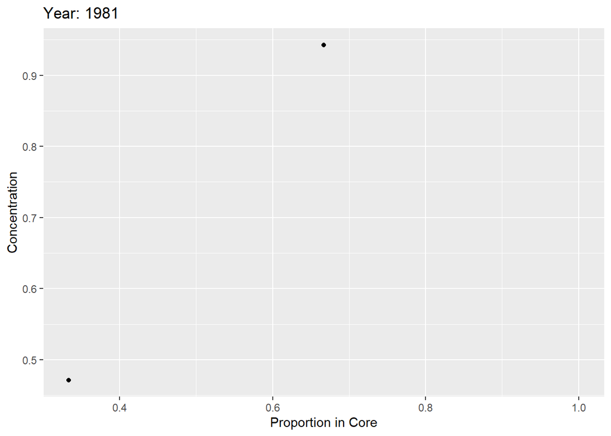

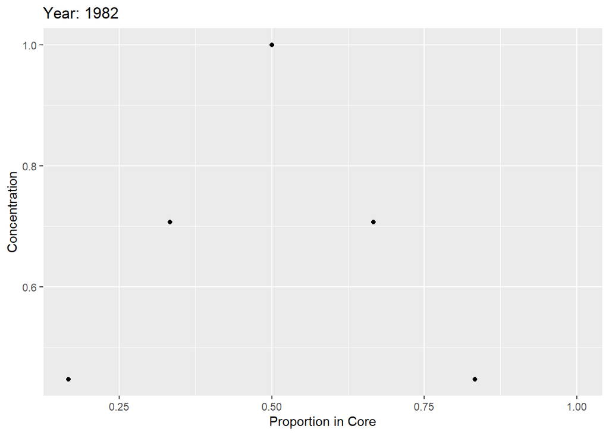

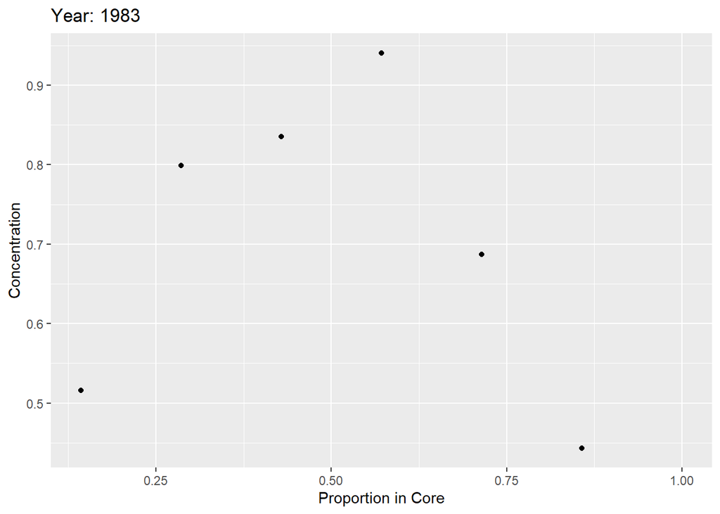

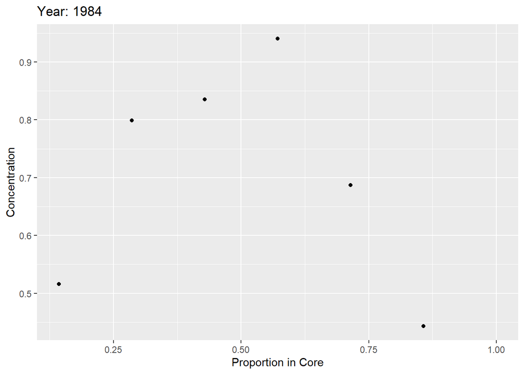

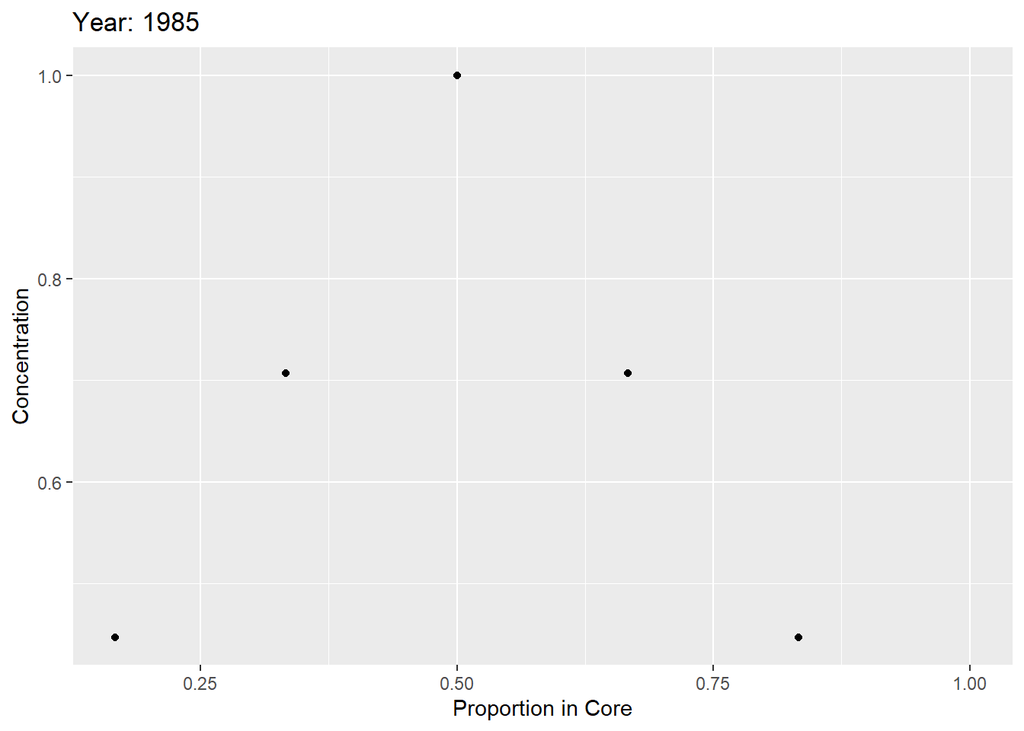

[figure not shown]

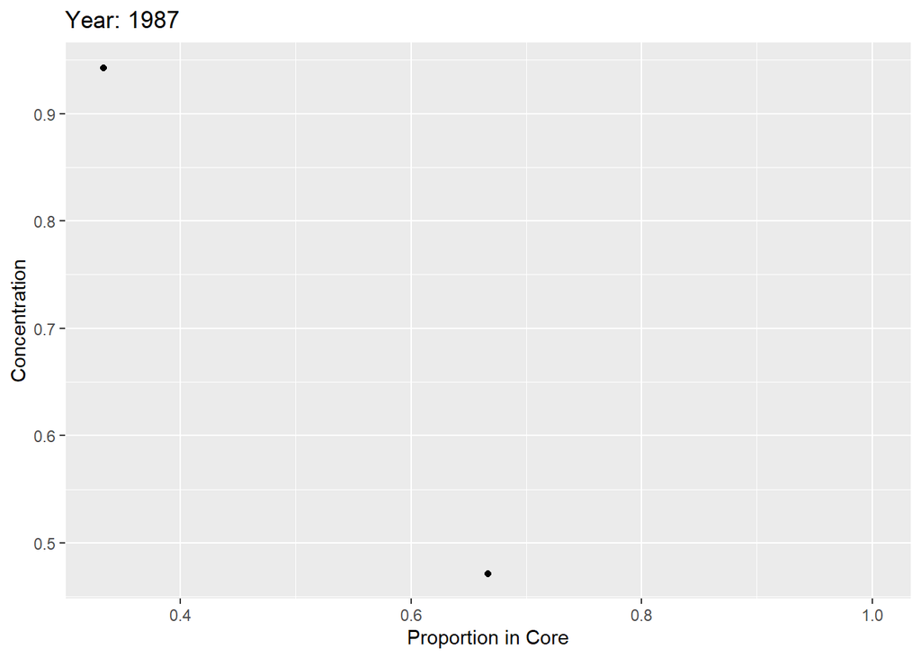

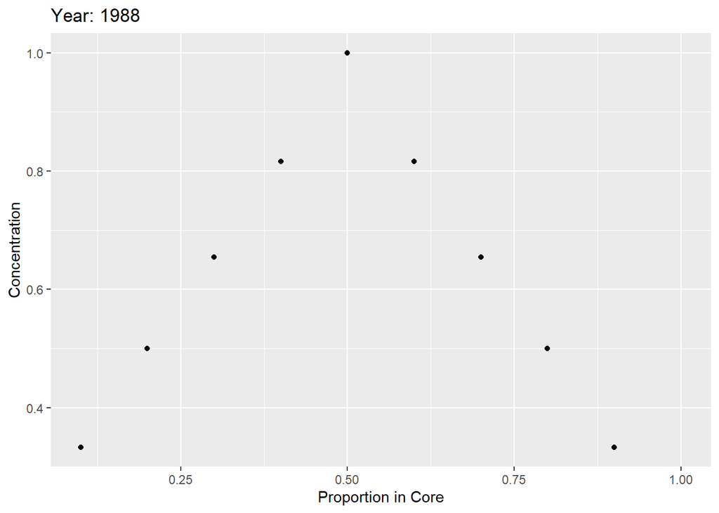

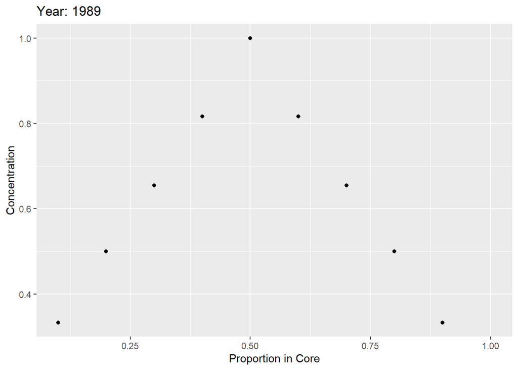

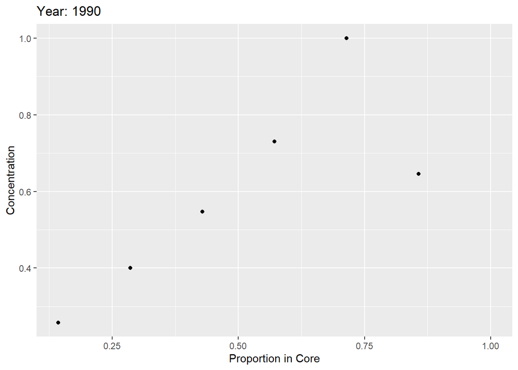

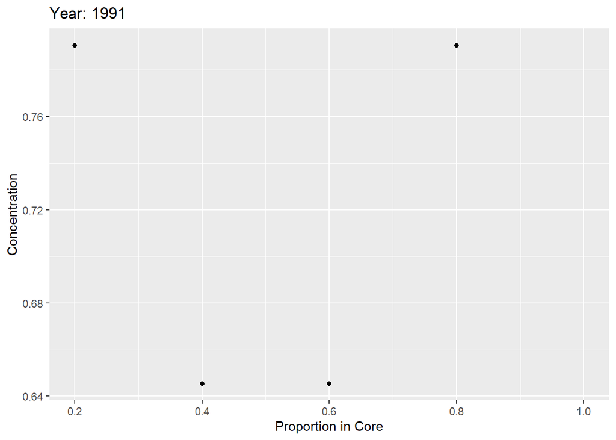

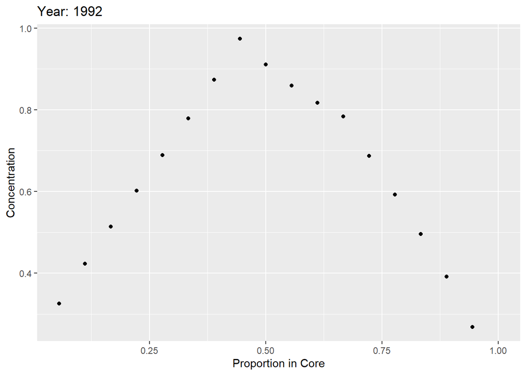

[22 more figures not shown]

```r
# plot the range of concentration scores for each partition size p
plts <- lapply(seq_along(tmp), function(i)
  ggplot(cov_dt[year==i])+
  geom_point(aes(x = prop, y = concentration))+
  ggtitle(paste('Year:', 1980+i))+
    xlab("Proportion in Core")+
    ylab("Concentration"))
plts
```

By the plots of concentration, we can clearly see that at the beginning the graphs are more speaded out. The high correlation happens at middle of the graph, indicating that there might not be a core, or might be mutiple small groups/cores. As year increasing, we can see that the correlation are more and more skew to the left, indicating the core-periphery structures are more and more developed and clear.

```r
#(B)
# Solution 1: measure dispersion of closeness

#calculate closeness for each year
close <- lapply(seq_along(tmp), function(i) closeness(g[[tmp[i]]]))
```

[output not shown]

[output cut: 34 more lines]

[output not shown]

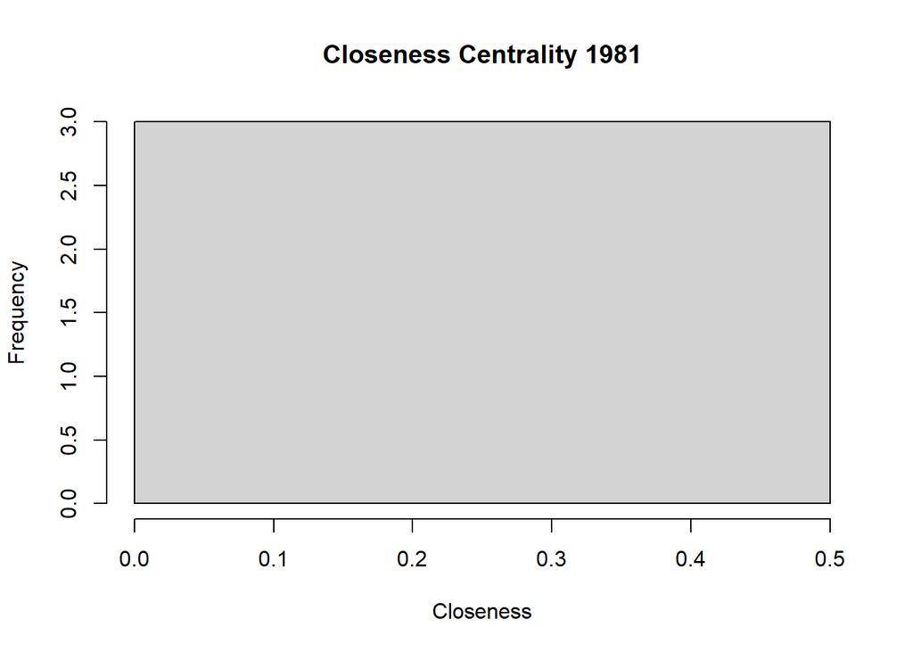

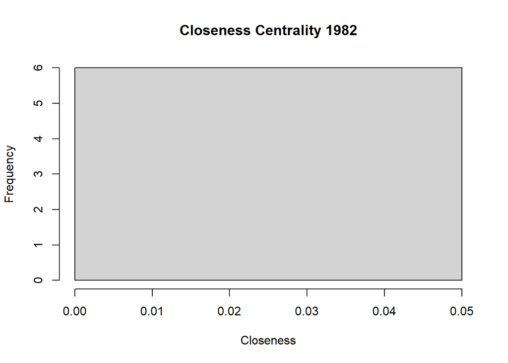

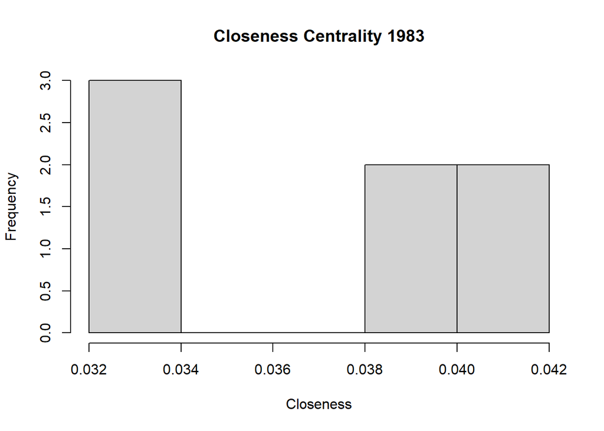

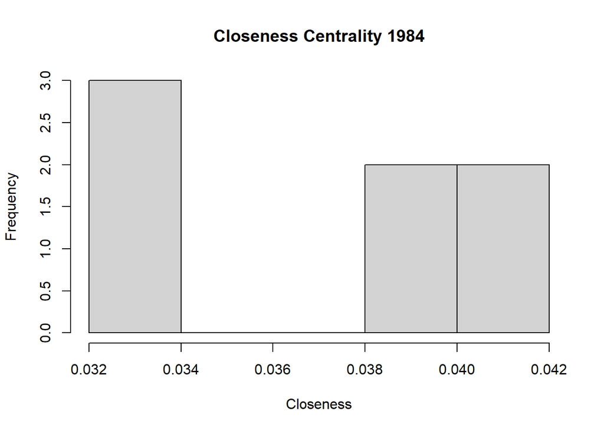

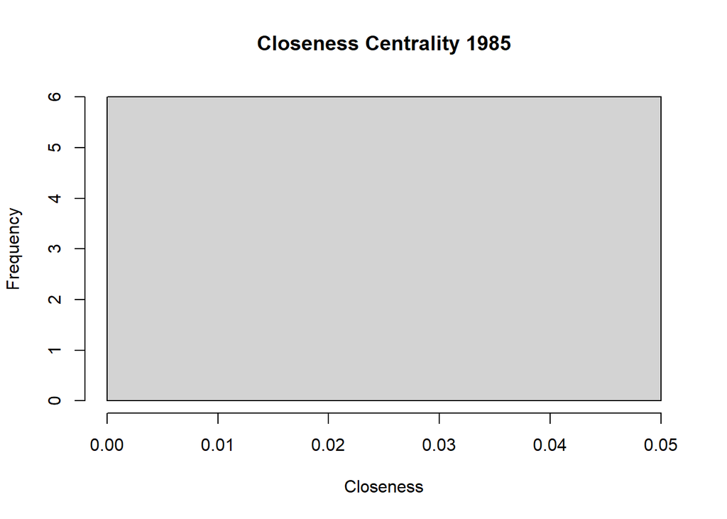

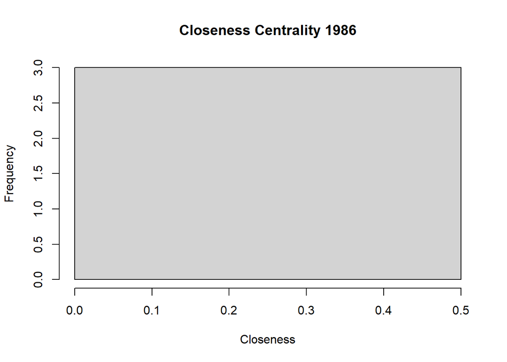

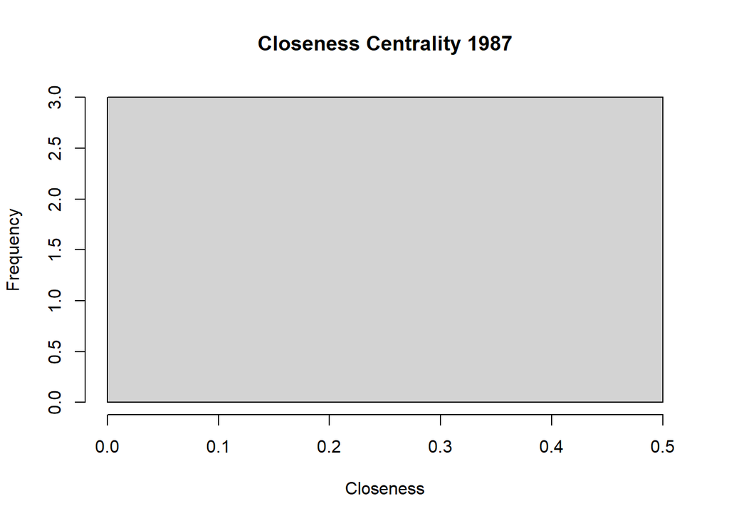

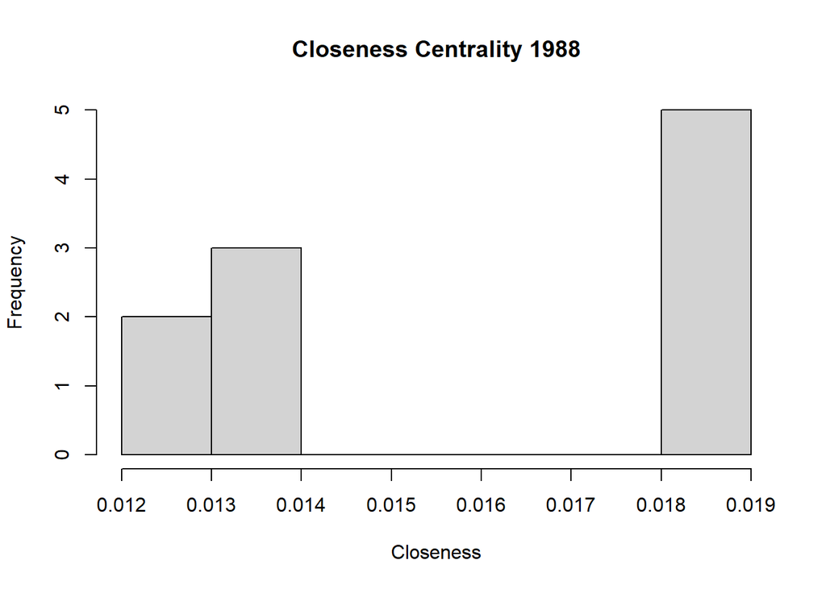

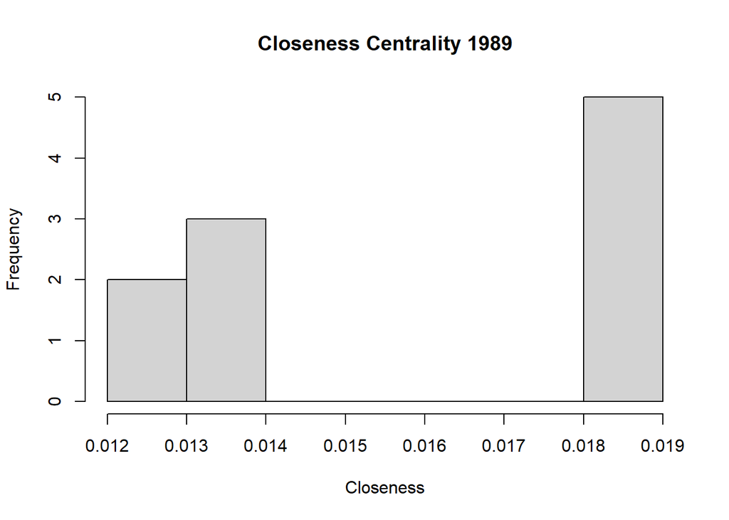

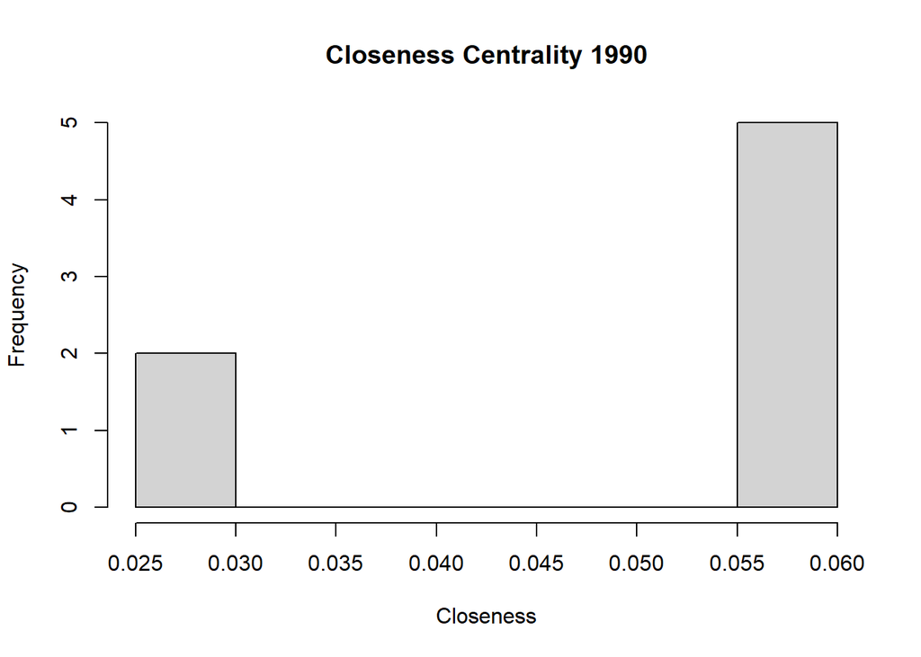

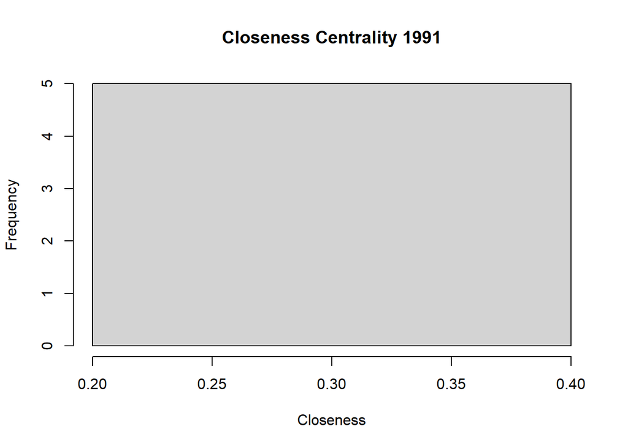

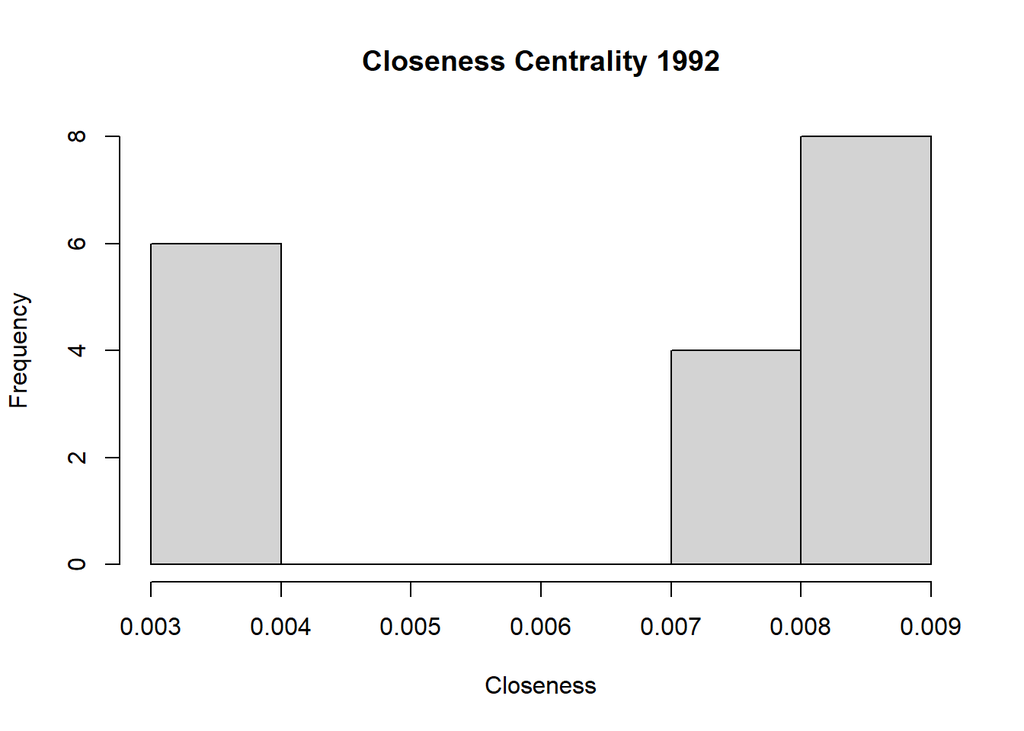

[22 more figures not shown]

[output not shown]

[output cut: 770 more lines]

[output not shown]

```r
#plot the histgram for each year
lapply(seq_along(close), function(i) hist(close[[i]],xlab = 'Closeness', main = paste('Closeness Centrality', 1980+i)))
```

Based on the distribution of closeness centrality, we can tell as the year increase the histograms become more and more separated in to two distinguished bars. The right bar get larger and larger, which means more and more nodes have large closeness. And there are still some nodes have small closeness at the left. This tells us There’s a core getting bigger and bigger and still some periphery around it.

```r
#Solution2: Multidimensional scaling

#produce distance matrix for each
dist <- lapply(seq_along(tmp), function(i) distances(g[[tmp[i]]]))

#replace Inf with 5 to aviod errors while scaling
for (i in seq_along(dist)){
  dist[[i]][dist[[i]] == Inf] = 5
}

#do a 2 dimension scaling by distances, the last 10 years taking way too long and the map is messy
#so here I use the first 22 years as an example
dist2 <- lapply(1:22, function(i) cmdscale(dist[[i]], k = 2))
```